# Time Series Project: Spring 2020

## 1 Dataset: [NOAA sea level rise from 1992-2019](https://www.climate.gov/maps-data/dataset/global-mean-sea-level-graph)

```r
library(tswge)
library(ggplot2)
library(lubridate)
library(knitr)
library(orcutt)
library(dplyr)
library(kableExtra)
library(corrplot)
library(tictoc)
library(imputeTS)
library(nnfor)
library(forecast)
library(vars)
#a e s t h e t i c
library(extrafont)
#library(vapoRwave) #thematic mismatch

sea = read.csv("D:/SMU/DS 6373 Time Series/NASA_sea_level_1993-2019.csv")

names(sea) <- c('altimeter', 'ID', 'date', 'obs', 'w_obs', 'GMSL.variation', 'GMSL.sd', 'GMSL.smoothed', 'GMSL.variation.GIA', 'GMSL.sd.GIA', 'GMSL.variation.GIA.smoothed', 'GMSL.variation.GIA.smoothed.no_yearly')
```

## 2 Response variable: Global Mean Sea Level with Global Isostatic Adjustment applied

This dataset contains global mean sea level averaged from satillite radar altimeters and land based tide gauges. The global isostatic adjustment is an offset to compensate for the elevation changing movement in the earth’s crust over time. If this isostatic movement occurs beneath an ocean, it can raise or lower sea levels in a measurable way. The timeframe for such movements is very long however, and something that should be isolated from other possible factors in sea level rise that are more volatile.

## 3 Client motivations for time series analysis

Potential clients for this type of data analysis could by anyone who intends to operate near an ocean long term. Companies involved in beachside tourist industries, like hotels or golf courses can use projected sea level rise as an element of cost benefit analysis when planning new installations. Wildlife conservatories overseeing areas like estuaries or costal waterways can use models of sea level rise to help determine what kind of conservations efforts can be taken. City planners and municipal authorities of coastal cities may find use for this data when considering infrastructure and budgeting affected by saltwater intrusions into freshwater aquifiers that supply thier cities. (add more later? more concrete examples)

Nasa sea level data from 1993 to 2019 has roughly 36 entries per year, so tri monthly entries variables are altimeter type - 0 = dual frequency, 999 = single frequency date, # of observations, # of weighted observations, and 7 types of sea level change measurement - 1 - Global Mean Sea Level (GMSL) variation with respect to 20year mean, (Global Isostatic Adjustment* not applied) 2 - GMSL standard deviation (no GIA) 3 - GMSL 60 day gaussian smoothing filter (no GIA) 4 - GMSL (with GIA) 5 - GMSL standard deviation (with GIA) 6 - GMSL w/gaussian smoothing (60 days) (with GIA) 7 - GMSL w/gaussian smoothing (60 days) (with GIA) with ‘annual and semi-annual signal removed’

- Date
- mean is derived from entries 121 - 858, which is years 1996-2016
- an issue, because i wish the actual numbers were given? maybe? post processed numbers are fine too i guess

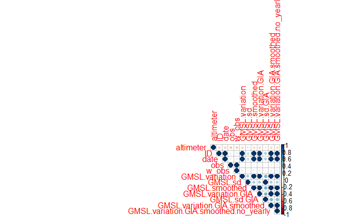

```r
s0 = cor(sea)
corrplot(s0, type = "upper")
```

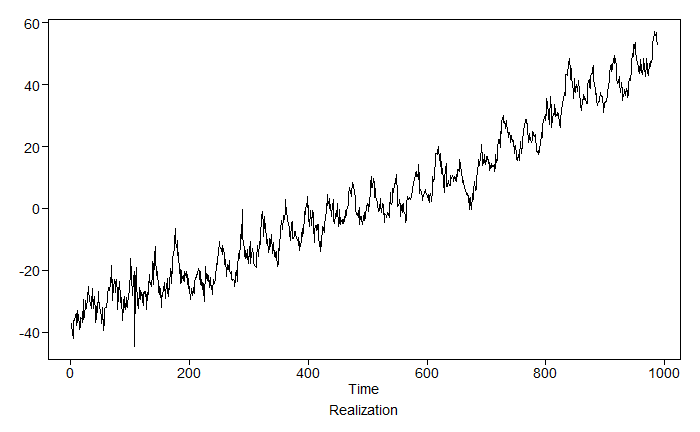

```r
#sea level initial visualizations
plotts.wge(sea$GMSL.variation)
```

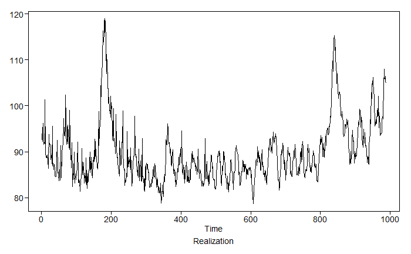

```r
plotts.wge(sea$GMSL.sd)
```

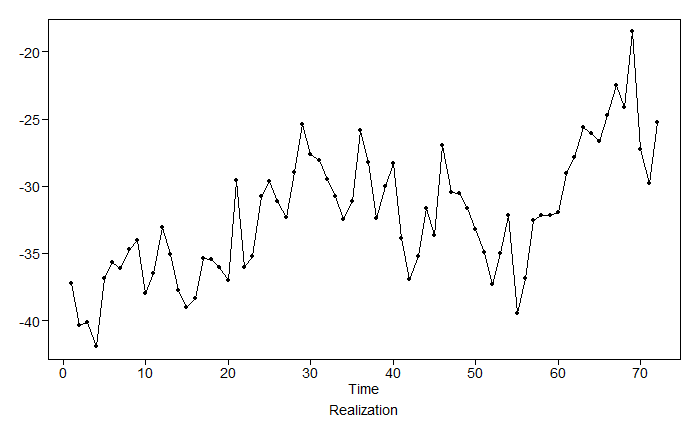

```r
plotts.wge(sea$GMSL.variation[1:72])
```

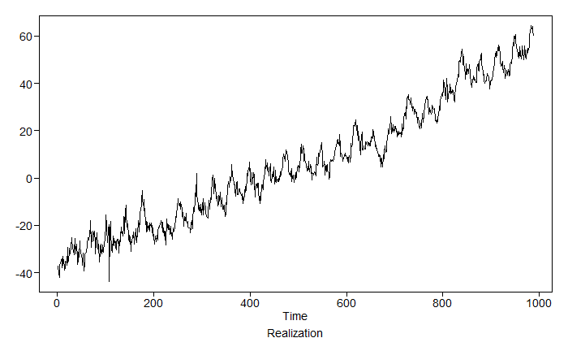

```r
plotts.wge(sea$GMSL.variation.GIA)
```

```r
plotts.sample.wge(sea$GMSL.variation.GIA)
```

[output not shown]

[output cut: 209 more lines]

[output not shown]

[output cut: 209 more lines]

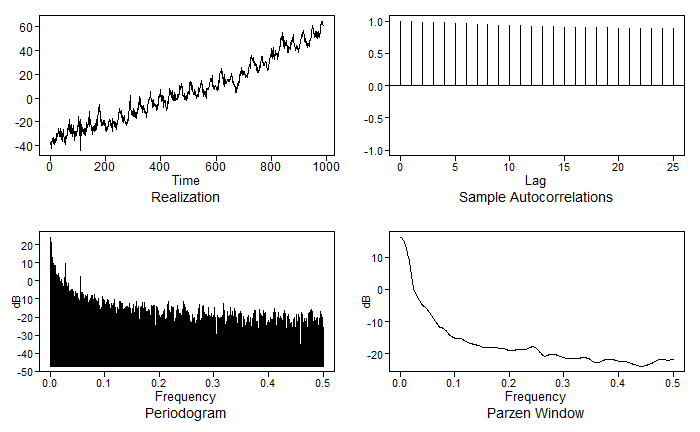

```r
plotts.sample.wge(sea$GMSL.variation.GIA)
```

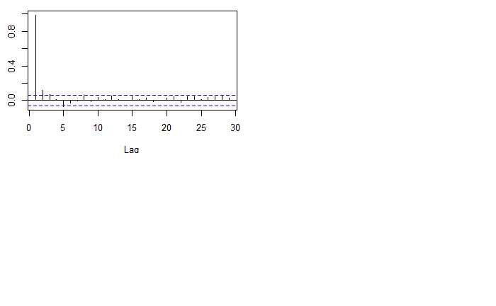

```r
pacf(sea$GMSL.variation.GIA)
```

very minor spike at .25, maybe 4 seasonality? acf doesn’t show much sign of stationarity, slowly damping high autocorrelations may indicate nonstationarity pacf has only 1 ish strong autocorrelations, so estimate for ar 1 or 2 ish?

#Section A: Univariate analysis